# Aula 10 - Introdução à Ciência dos Dados

Seu Nome

2023-05-25

# Regressão Linear Múltipla em R

## Aplicação: Modelos de Precificação e Regressão Hedônicos

Modelos de precificação hedônica tratam um bem comercializado, geralmente uma casa, como uma soma de bens individuais (características ou atributos) que não podem ser vendidos separadamente no mercado. O principal objetivo de um modelo de precificação hedônico é estimar a contribuição de tais características ou atributos para o preço da casa. É por isso que eles se tornaram uma estratégia central para estimar os preços implícitos de bens não comercializáveis.

A regressão hedônica é um método de preferência revelada para estimar o valor monetário das características de um bem. Decompõe o bem ou item pesquisado em suas características e obtém estimativas da contribuição de valor monetário de cada característica. Os modelos de regressão hedônica são mais comumente estimados por meio de análise de regressão, onde o preço geral do bem é tratado como a variável dependente e as características do bem se tornam as variáveis preditoras.

Os modelos hedônicos são comumente usados na avaliação imobiliária, pois as casas têm uma variedade de características facilmente mensuráveis (como o número de quartos, tamanho total ou distância de certas comodidades) que as tornam mais passíveis de modelos de regressão hedônica do que a maioria dos outros bens.

Neste tipo de aplicação, estamos geralmente mais interessados na acurácia preditiva do modelo, ou seja, desejamos um modelo capaz de prever com boa acurária o valor de um imóvel, dadas suas caracaterísticas e não temos interesse relevante nas estimativas pontuais dos parâmetros do modelo de regressão.

## 1. Setup

```r
knitr::opts_chunk$set(digits = 5, scipen = 9999, warning = FALSE, message = FALSE)

# pacotes utilizados
library(tidyverse)
library(tidymodels)
library(MASS)
library(Hmisc)
```

## 2. O metapacote `tidymodels`

`tidymodels` é um metapacote que contém uma coleção de pacotes para modelagem e aprendizado de máquina usando os princípios do `tidyverse`. Todos os pacotes dessa família são projetados para serem consistentes, modulares e para suportar boas práticas de modelagem.

## 3. Dados

O conjunto de dados `?MASS::Boston` refere-se ao conjunto de dados de preços de imóveis em Boston, e contém informações sobre 506 imóveis e sobre 14 características desses imóveis.

Vejamos os nomes das variáveis contidas no objeto:

```r
data(Boston)
names(Boston)
```

```
##  [1] "crim"    "zn"      "indus"   "chas"    "nox"     "rm"      "age"
##  [8] "dis"     "rad"     "tax"     "ptratio" "black"   "lstat"   "medv"
```

E a classe/tipo de cada uma das variáveis:

```r
glimpse(Boston)
```

```
## Rows: 506
## Columns: 14
## $ crim    <dbl> 0.00632, 0.02731, 0.02729, 0.03237, 0.06905, 0.02985, 0.08829,…
## $ zn      <dbl> 18.0, 0.0, 0.0, 0.0, 0.0, 0.0, 12.5, 12.5, 12.5, 12.5, 12.5, 1…
## $ indus   <dbl> 2.31, 7.07, 7.07, 2.18, 2.18, 2.18, 7.87, 7.87, 7.87, 7.87, 7.…
## $ chas    <int> 0, 0, 0, 0, 0, 0, 0, 0, 0, 0, 0, 0, 0, 0, 0, 0, 0, 0, 0, 0, 0,…
## $ nox     <dbl> 0.538, 0.469, 0.469, 0.458, 0.458, 0.458, 0.524, 0.524, 0.524,…
## $ rm      <dbl> 6.575, 6.421, 7.185, 6.998, 7.147, 6.430, 6.012, 6.172, 5.631,…
## $ age     <dbl> 65.2, 78.9, 61.1, 45.8, 54.2, 58.7, 66.6, 96.1, 100.0, 85.9, 9…
## $ dis     <dbl> 4.0900, 4.9671, 4.9671, 6.0622, 6.0622, 6.0622, 5.5605, 5.9505…
## $ rad     <int> 1, 2, 2, 3, 3, 3, 5, 5, 5, 5, 5, 5, 5, 4, 4, 4, 4, 4, 4, 4, 4,…
## $ tax     <dbl> 296, 242, 242, 222, 222, 222, 311, 311, 311, 311, 311, 311, 31…
## $ ptratio <dbl> 15.3, 17.8, 17.8, 18.7, 18.7, 18.7, 15.2, 15.2, 15.2, 15.2, 15…
## $ black   <dbl> 396.90, 396.90, 392.83, 394.63, 396.90, 394.12, 395.60, 396.90…
## $ lstat   <dbl> 4.98, 9.14, 4.03, 2.94, 5.33, 5.21, 12.43, 19.15, 29.93, 17.10…
## $ medv    <dbl> 24.0, 21.6, 34.7, 33.4, 36.2, 28.7, 22.9, 27.1, 16.5, 18.9, 15…
```

Estatística descritivas:

```r
summary(Boston)
```

```
##       crim                zn             indus            chas
##  Min.   : 0.00632   Min.   :  0.00   Min.   : 0.46   Min.   :0.00000
##  1st Qu.: 0.08205   1st Qu.:  0.00   1st Qu.: 5.19   1st Qu.:0.00000
##  Median : 0.25651   Median :  0.00   Median : 9.69   Median :0.00000
##  Mean   : 3.61352   Mean   : 11.36   Mean   :11.14   Mean   :0.06917
##  3rd Qu.: 3.67708   3rd Qu.: 12.50   3rd Qu.:18.10   3rd Qu.:0.00000
##  Max.   :88.97620   Max.   :100.00   Max.   :27.74   Max.   :1.00000
##       nox               rm             age              dis
##  Min.   :0.3850   Min.   :3.561   Min.   :  2.90   Min.   : 1.130
##  1st Qu.:0.4490   1st Qu.:5.886   1st Qu.: 45.02   1st Qu.: 2.100
##  Median :0.5380   Median :6.208   Median : 77.50   Median : 3.207
##  Mean   :0.5547   Mean   :6.285   Mean   : 68.57   Mean   : 3.795
##  3rd Qu.:0.6240   3rd Qu.:6.623   3rd Qu.: 94.08   3rd Qu.: 5.188
##  Max.   :0.8710   Max.   :8.780   Max.   :100.00   Max.   :12.127
##       rad              tax           ptratio          black
##  Min.   : 1.000   Min.   :187.0   Min.   :12.60   Min.   :  0.32
##  1st Qu.: 4.000   1st Qu.:279.0   1st Qu.:17.40   1st Qu.:375.38
##  Median : 5.000   Median :330.0   Median :19.05   Median :391.44
##  Mean   : 9.549   Mean   :408.2   Mean   :18.46   Mean   :356.67
##  3rd Qu.:24.000   3rd Qu.:666.0   3rd Qu.:20.20   3rd Qu.:396.23
##  Max.   :24.000   Max.   :711.0   Max.   :22.00   Max.   :396.90
##      lstat            medv
##  Min.   : 1.73   Min.   : 5.00
##  1st Qu.: 6.95   1st Qu.:17.02
##  Median :11.36   Median :21.20
##  Mean   :12.65   Mean   :22.53
##  3rd Qu.:16.95   3rd Qu.:25.00
##  Max.   :37.97   Max.   :50.00
```

## 4. Preparação dos Dados para Treinamento e Teste

A função `initial_split()` foi criada especialmente para separar o conjunto de dados em um conjunto de treinamento e teste. Por padrão, ele armazena 3/4 dos dados para treinamento e o restante para teste.

Isso pode ser alterado usando o argumento `prop`. Esta função gera um objeto `rplit`, não uma `data.frame` ou `tibble`. A saída mostra a contagem de linhas para treinamento, teste e total:

```r
set.seed(4595)
boston_split <- initial_split(Boston, strata = "medv", prop = 0.75)
boston_split
```

```
## <Training/Testing/Total>
## <378/128/506>
```

```r
# datos para treinamento
boston_train <- training(boston_split)

# dados para teste
boston_test  <- testing(boston_split)
```

Estamos prontos para treinar um modelo ajustando um algoritmo de regressão adequado aos dados de treinamento.

## 5. Treinamento do Modelo de Regressão

```r
## define a especificao de um modelo de reg. linear
mod_reg_linear <-
  linear_reg() |>
  set_mode("regression") |>
  set_engine("lm")

## treinando um modelo de regressao linear
reg_fit <- mod_reg_linear |>
    fit(medv ~ ., data = boston_train)
```

## 6. Avaliando a Capacidade Preditiva do Modelo

Agora, podemos testar o modelo treinado (ajustado aos dados de treinamento) nos dados de teste, que não foram utilizados na fase de treinamento.

Usando a função `predict()` podemos obter previsões para os dados de teste a partir do modelo estimado com os dados para treinamento.

O código a seguir, além de obter as previsões para os dados de teste, funde as previsões com os dados de teste:

```r
resultado_reglin <- reg_fit |>
  predict(boston_test) |>
  bind_cols(boston_test) |>
  rename(.pred_lm = .pred)

resultado_reglin |> dplyr::select(medv, .pred_lm)
```

```
## # A tibble: 128 × 2
##     medv .pred_lm
##    <dbl>    <dbl>
##  1  21.6     25.1
##  2  36.2     28.0
##  3  22.9     22.7
##  4  27.1     18.6
##  5  21.7     20.6
##  6  20.4     19.6
##  7  13.6     11.9
##  8  14.5     13.2
##  9  14.8     14.2
## 10  12.7     10.7
## # ℹ 118 more rows
```

```r
head(resultado_reglin, 20)
```

```
## # A tibble: 20 × 15
##    .pred_lm   crim    zn indus  chas   nox    rm   age   dis   rad   tax ptratio
##       <dbl>  <dbl> <dbl> <dbl> <int> <dbl> <dbl> <dbl> <dbl> <int> <dbl>   <dbl>
##  1    25.1  0.0273   0    7.07     0 0.469  6.42  78.9  4.97     2   242    17.8
##  2    28.0  0.0690   0    2.18     0 0.458  7.15  54.2  6.06     3   222    18.7
##  3    22.7  0.0883  12.5  7.87     0 0.524  6.01  66.6  5.56     5   311    15.2
##  4    18.6  0.145   12.5  7.87     0 0.524  6.17  96.1  5.95     5   311    15.2
##  5    20.6  0.0938  12.5  7.87     0 0.524  5.89  39    5.45     5   311    15.2
##  6    19.6  0.630    0    8.14     0 0.538  5.95  61.8  4.71     4   307    21
##  7    11.9  1.25     0    8.14     0 0.538  5.57  98.1  3.80     4   307    21
##  8    13.2  0.988    0    8.14     0 0.538  5.81 100    4.10     4   307    21
##  9    14.2  0.956    0    8.14     0 0.538  6.05  88.8  4.45     4   307    21
## 10    10.7  1.13     0    8.14     0 0.538  5.71  94.1  4.23     4   307    21
## 11     7.81 1.39     0    8.14     0 0.538  5.95  82    3.99     4   307    21
## 12    23.4  0.0801   0    5.96     0 0.499  5.85  41.5  3.93     5   279    19.2
## 13    23.2  0.175    0    5.96     0 0.499  5.97  30.2  3.85     5   279    19.2
## 14    22.3  0.171    0    6.91     0 0.448  5.68  33.8  5.10     3   233    17.9
## 15    21.1  0.0887  21    5.64     0 0.439  5.96  45.7  6.81     4   243    16.8
## 16    15.4  0.0136  75    4        0 0.41   5.89  47.6  7.32     3   469    21.1
## 17    33.9  0.0143 100    1.32     0 0.411  6.82  40.5  8.32     5   256    15.1
## 18    21.1  0.103   25    5.13     0 0.453  5.93  47.2  6.93     8   284    19.7
## 19    31.4  0.0358  80    3.37     0 0.398  6.29  17.8  6.61     4   337    16.1
## 20    26.1  0.0438  80    3.37     0 0.398  5.79  31.1  6.61     4   337    16.1
## # ℹ 3 more variables: black <dbl>, lstat <dbl>, medv <dbl>
```

```r
resultado_reglin |> metrics(truth = medv, estimate = .pred_lm)
```

```
## # A tibble: 3 × 3
##   .metric .estimator .estimate
##   <chr>   <chr>          <dbl>
## 1 rmse    standard       4.57
## 2 rsq     standard       0.713
## 3 mae     standard       3.47
```

Visualizando os dados de teste e as previsões do modelo de regressão linear:

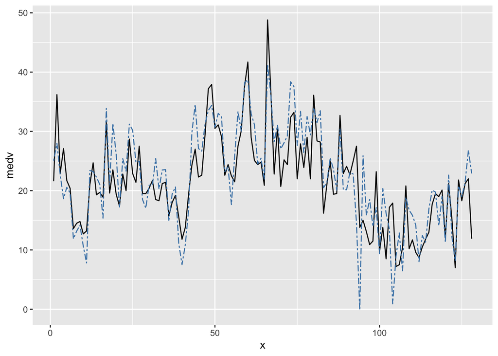

```r
mod_reg <- resultado_reglin %>% mutate(x = 1:128)

ggplot(mod_reg, aes(x = x)) +
  geom_line(aes(y = medv), color = "black") +
  geom_line(aes(y = .pred_lm), color = "steelblue", linetype = "twodash")
```

Você consegue observar os dados de teste para os quais o modelo de regressão linear múltipla não produz boas previsões?

## Modelos de Aprendizagem de Máquina baseados em Populações

1. Especificação e treinamento de um modelo Random Forest

```r
# Para reproducibilidade
set.seed(2056)

# define a especificacao de um modelo Random Forest
rf_spec <- rand_forest() |>
  set_mode('regression') |>
  set_engine('randomForest')


# Treina um modelo random forest
rf_mod <- rf_spec |>
  fit(medv ~ ., data = boston_train)
```

2. Avaliação da capacidade preditiva do modelo Random Forest

```r
rf_testfit <- rf_mod |>
  predict(boston_test) |>
  bind_cols(boston_test)

rf_testfit |> dplyr::select(medv, .pred)
```

```
## # A tibble: 128 × 2
##     medv .pred
##    <dbl> <dbl>
##  1  21.6  23.2
##  2  36.2  32.8
##  3  22.9  20.1
##  4  27.1  17.6
##  5  21.7  20.1
##  6  20.4  20.4
##  7  13.6  15.1
##  8  14.5  15.7
##  9  14.8  15.6
## 10  12.7  14.8
## # ℹ 118 more rows
```

```r
head(rf_testfit, 20)
```

```
## # A tibble: 20 × 15
##    .pred   crim    zn indus  chas   nox    rm   age   dis   rad   tax ptratio
##    <dbl>  <dbl> <dbl> <dbl> <int> <dbl> <dbl> <dbl> <dbl> <int> <dbl>   <dbl>
##  1  23.2 0.0273   0    7.07     0 0.469  6.42  78.9  4.97     2   242    17.8
##  2  32.8 0.0690   0    2.18     0 0.458  7.15  54.2  6.06     3   222    18.7
##  3  20.1 0.0883  12.5  7.87     0 0.524  6.01  66.6  5.56     5   311    15.2
##  4  17.6 0.145   12.5  7.87     0 0.524  6.17  96.1  5.95     5   311    15.2
##  5  20.1 0.0938  12.5  7.87     0 0.524  5.89  39    5.45     5   311    15.2
##  6  20.4 0.630    0    8.14     0 0.538  5.95  61.8  4.71     4   307    21
##  7  15.1 1.25     0    8.14     0 0.538  5.57  98.1  3.80     4   307    21
##  8  15.7 0.988    0    8.14     0 0.538  5.81 100    4.10     4   307    21
##  9  15.6 0.956    0    8.14     0 0.538  6.05  88.8  4.45     4   307    21
## 10  14.8 1.13     0    8.14     0 0.538  5.71  94.1  4.23     4   307    21
## 11  15.4 1.39     0    8.14     0 0.538  5.95  82    3.99     4   307    21
## 12  21.1 0.0801   0    5.96     0 0.499  5.85  41.5  3.93     5   279    19.2
## 13  21.3 0.175    0    5.96     0 0.499  5.97  30.2  3.85     5   279    19.2
## 14  20.5 0.171    0    6.91     0 0.448  5.68  33.8  5.10     3   233    17.9
## 15  20.7 0.0887  21    5.64     0 0.439  5.96  45.7  6.81     4   243    16.8
## 16  20.0 0.0136  75    4        0 0.41   5.89  47.6  7.32     3   469    21.1
## 17  32.8 0.0143 100    1.32     0 0.411  6.82  40.5  8.32     5   256    15.1
## 18  20.9 0.103   25    5.13     0 0.453  5.93  47.2  6.93     8   284    19.7
## 19  27.7 0.0358  80    3.37     0 0.398  6.29  17.8  6.61     4   337    16.1
## 20  21.1 0.0438  80    3.37     0 0.398  5.79  31.1  6.61     4   337    16.1
## # ℹ 3 more variables: black <dbl>, lstat <dbl>, medv <dbl>
```

```r
rf_testfit |>
  metrics(truth = medv, estimate = .pred)
```

```
## # A tibble: 3 × 3
##   .metric .estimator .estimate
##   <chr>   <chr>          <dbl>
## 1 rmse    standard       2.72
## 2 rsq     standard       0.874
## 3 mae     standard       2.03
```

3. Visualização das Previsões e dos Dados de Teste

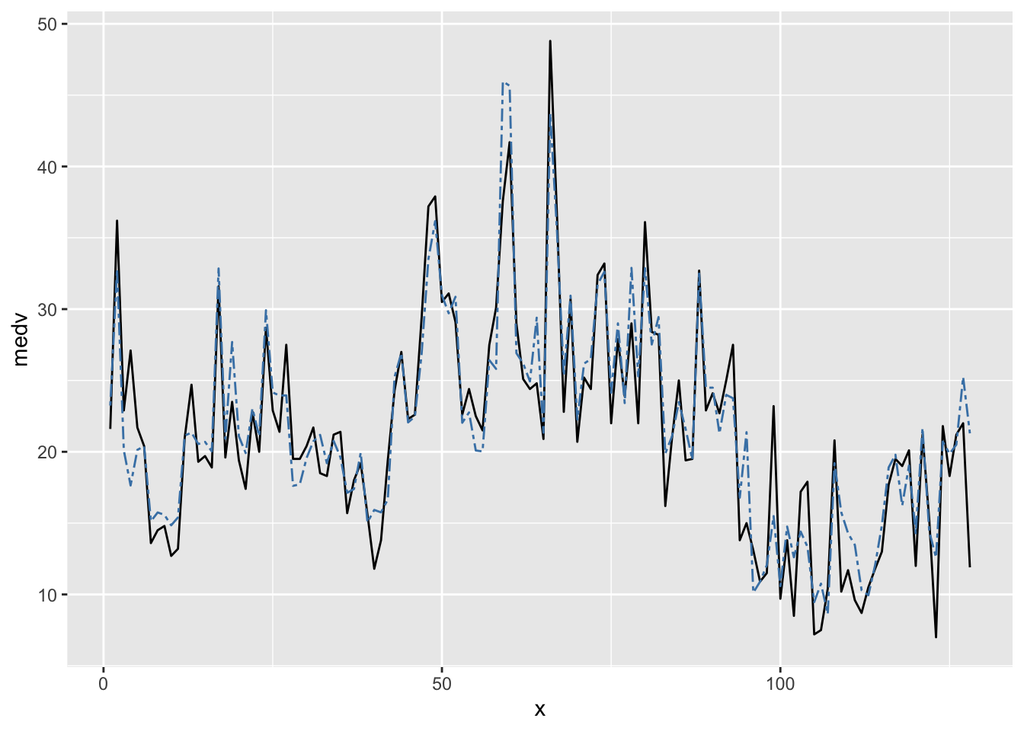

```r
mod_rf <- rf_testfit |> mutate(x = 1:128)

ggplot(mod_rf, aes(x = x)) +
  geom_line(aes(y = medv), color = "black") +
  geom_line(aes(y = .pred), color = "steelblue", linetype = "twodash")
```